# pac_jem_study

For a difference-in-difference analysis to be valid, there must be parallel trends prior to the intervention. Difference in difference design assumes that the treatment and control groups were going along the same trajectory before the intervention. Every force that acts on the treatment group has an equal effect on the treatment group. So when the treatment group increases or decreases, so does the control. The change in the control group after the intervention shows what kind of change you would have expected the treatment group to see, had the treatment not occurred.

The calculation of the “difference in the differences” only works if you can demonstrate parallel trends prior to the intervention. Otherwise there is/are other forces that act differently between the two groups. Those other forces may be accounting for the difference between the groups before and after the intervention, and therefore your calculation of the “difference in differences” won’t actually measure the impact of the intervention (elimination of fees) but several things which are impossible to untangle from each other (the elimination of fees and all the other forces that result in lack of parallel trends).

Any analyses that do not demonstrate parallel trends prior to the intervention should be considered invalid. **Because this document is built to change as more data is added, know that if the plots do not demonstrate parallel trends, the calculations shown and conclusions drawn are not valid**

### Difference in difference results:

#### (EM rate mean, weighted by population)

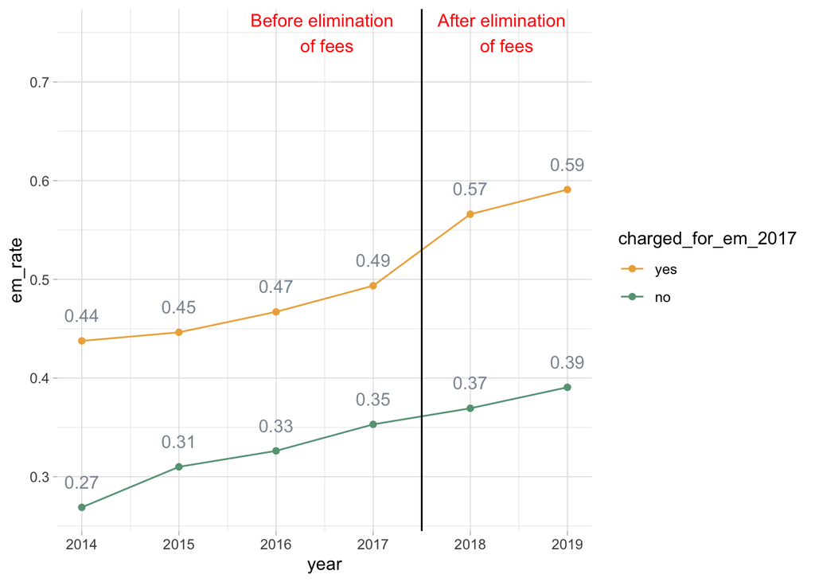

The weighted mean difference after the elimination of fees for counties that charged fees was 7.2 percentage points.

For counties that did not charge fees, the elimination of fees changed utilization of EM by 1.6 percentage points.

Therefore, the difference in differences is 7.2 - 1.6 = 5.6 percentage points.

**In this model, eliminating fees INCREASED utilization of electronic monitoring by 5.6 percentage points.**

| charged_for_em_2017 | diff |
| --- | --- |
| no | 0.0162874 |
| yes | 0.0724937 |

#### Sample sizes by group and year:

| year | county | charged_for_em_2017 | n |
| --- | --- | --- | --- |
| 2014 | weighted_average_no_fee | no | 14 |
| 2015 | weighted_average_no_fee | no | 15 |
| 2016 | weighted_average_no_fee | no | 15 |
| 2017 | weighted_average_no_fee | no | 15 |
| 2018 | weighted_average_no_fee | no | 15 |
| 2019 | weighted_average_no_fee | no | 15 |
| 2014 | weighted_average_with_fee | yes | 8 |
| 2015 | weighted_average_with_fee | yes | 10 |
| 2016 | weighted_average_with_fee | yes | 11 |
| 2017 | weighted_average_with_fee | yes | 12 |
| 2018 | weighted_average_with_fee | yes | 12 |
| 2019 | weighted_average_with_fee | yes | 11 |

#### Counties included for each year

| county | pop | weight | pop_rank | charged_for_em_2017 | 2014 | 2015 | 2016 | 2017 | 2018 | 2019 |
| --- | --- | --- | --- | --- | --- | --- | --- | --- | --- | --- |
| Orange | 3164182 | 0.3897140 | 3 | no | Yes | Yes | Yes | Yes | Yes | Yes |
| Santa_Clara | 1922200 | 0.2348930 | 6 | yes | Yes | Yes | Yes | Yes | Yes | Yes |
| Alameda | 1643700 | 0.2008603 | 7 | yes | Yes | Yes | Yes | Yes | Yes | Yes |
| Sacramento | 1510023 | 0.1845250 | 8 | yes | Yes | Yes | Yes | Yes | Yes | Yes |
| Fresno | 978130 | 0.1195276 | 10 | yes | Yes | Yes | Yes | Yes | Yes | Yes |
| Kern | 883053 | 0.1087605 | 11 | no | Yes | Yes | Yes | Yes | Yes | Yes |
| San_Francisco | 870044 | 0.1071583 | 12 | no | Yes | Yes | Yes | Yes | Yes | Yes |
| Ventura | 848112 | 0.1036394 | 13 | yes | Yes | Yes | Yes | Yes | Yes | Yes |
| San_Joaquin | 732212 | 0.0901823 | 15 | no | Yes | Yes | Yes | Yes | Yes | Yes |
| Stanislaus | 539301 | 0.0664226 | 16 | no | Yes | Yes | Yes | Yes | Yes | Yes |
| Sonoma | 501317 | 0.0617443 | 17 | no | Yes | Yes | Yes | Yes | Yes | Yes |
| Tulare | 460477 | 0.0562703 | 18 | yes | Yes | Yes | Yes | Yes | Yes | Yes |
| Santa_Barbara | 443738 | 0.0546526 | 19 | no | Yes | Yes | Yes | Yes | Yes | Yes |
| Placer | 380077 | 0.0468119 | 22 | no | Yes | Yes | Yes | Yes | Yes | Yes |
| San_Luis_Obispo | 281455 | 0.0343938 | 23 | yes | – | – | Yes | Yes | Yes | Yes |
| Santa_Cruz | 273765 | 0.0337181 | 24 | no | Yes | Yes | Yes | Yes | Yes | Yes |
| Marin | 260295 | 0.0318081 | 26 | yes | – | Yes | Yes | Yes | Yes | Yes |
| El_Dorado | 186661 | 0.0229900 | 29 | no | Yes | Yes | Yes | Yes | Yes | Yes |
| Humboldt | 135768 | 0.0165909 | 35 | yes | Yes | Yes | Yes | Yes | Yes | Yes |
| Nevada | 99092 | 0.0121091 | 36 | yes | – | – | Yes | Yes | Yes | Yes |
| Siskiyou | 43540 | 0.0053626 | 45 | no | Yes | Yes | Yes | Yes | Yes | Yes |
| Amador | 37829 | 0.0046592 | 46 | no | Yes | Yes | Yes | Yes | Yes | Yes |
| Lassen | 31185 | 0.0038108 | 47 | yes | Yes | Yes | Yes | Yes | Yes | Yes |
| Glenn | 27897 | 0.0034359 | 48 | no | Yes | Yes | Yes | Yes | Yes | Yes |
| Inyo | 18085 | 0.0022274 | 52 | no | Yes | Yes | Yes | Yes | Yes | Yes |
| Mariposa | 17540 | 0.0021603 | 53 | no | – | Yes | Yes | Yes | Yes | Yes |
| Trinity | 12862 | 0.0015717 | 55 | yes | – | Yes | – | Yes | Yes | – |

#### Calculations county-by-county

These numbers were then averaged using the weights shown, and plotted above.

| county | charged_for_em_2017 | pop | y2017 | y2018 | diff | weight |
| --- | --- | --- | --- | --- | --- | --- |
| Orange | no | 3164182 | 0.4056757 | 0.4355985 | 0.0299228 | 0.3897140 |
| Santa_Clara | yes | 1922200 | 0.3359712 | 0.4677524 | 0.1317812 | 0.2348930 |
| Alameda | yes | 1643700 | 0.5841035 | 0.6098485 | 0.0257450 | 0.2008603 |
| Sacramento | yes | 1510023 | 1.0765896 | 1.2364865 | 0.1598969 | 0.1845250 |
| Fresno | yes | 978130 | 0.0935829 | 0.0977676 | 0.0041848 | 0.1195276 |
| Kern | no | 883053 | 0.0033956 | 0.0035587 | 0.0001631 | 0.1087605 |
| San_Francisco | no | 870044 | 0.1648352 | 0.2785571 | 0.1137219 | 0.1071583 |
| Ventura | yes | 848112 | 0.3854003 | 0.3654342 | -0.0199661 | 0.1036394 |
| San_Joaquin | no | 732212 | 0.2393701 | 0.2749035 | 0.0355334 | 0.0901823 |
| Stanislaus | no | 539301 | 0.3822976 | 0.4800000 | 0.0977024 | 0.0664226 |
| Sonoma | no | 501317 | 0.8839506 | 0.7675439 | -0.1164068 | 0.0617443 |
| Tulare | yes | 460477 | 0.3577586 | 0.3375000 | -0.0202586 | 0.0562703 |
| Santa_Barbara | no | 443738 | 0.4236220 | 0.4400922 | 0.0164701 | 0.0546526 |
| Placer | no | 380077 | 0.5359477 | 0.2443182 | -0.2916295 | 0.0468119 |
| San_Luis_Obispo | yes | 281455 | 0.2994012 | 0.3766234 | 0.0772222 | 0.0343938 |
| Santa_Cruz | no | 273765 | 0.3216374 | 0.3712375 | 0.0496000 | 0.0337181 |
| Marin | yes | 260295 | 0.2585034 | 0.4531250 | 0.1946216 | 0.0318081 |
| El_Dorado | no | 186661 | 0.3137255 | 0.3913043 | 0.0775789 | 0.0229900 |
| Humboldt | yes | 135768 | 0.2528090 | 0.2298851 | -0.0229239 | 0.0165909 |
| Nevada | yes | 99092 | 0.3508772 | 0.4395604 | 0.0886832 | 0.0121091 |
| Siskiyou | no | 43540 | 1.5384615 | 1.1538462 | -0.3846154 | 0.0053626 |
| Amador | no | 37829 | 0.1538462 | 0.2857143 | 0.1318681 | 0.0046592 |
| Lassen | yes | 31185 | 0.0769231 | 0.0689655 | -0.0079576 | 0.0038108 |
| Glenn | no | 27897 | 0.0294118 | 0.0444444 | 0.0150327 | 0.0034359 |
| Inyo | no | 18085 | 0.0000000 | 0.2727273 | 0.2727273 | 0.0022274 |
| Mariposa | no | 17540 | 0.0000000 | 0.0000000 | 0.0000000 | 0.0021603 |
| Trinity | yes | 12862 | 0.0714286 | 0.1111111 | 0.0396825 | 0.0015717 |

### Same thing, but using an un-weighted mean

At the time of writing, this does not show parallel trends, so any calculation / interpretation is invalid.

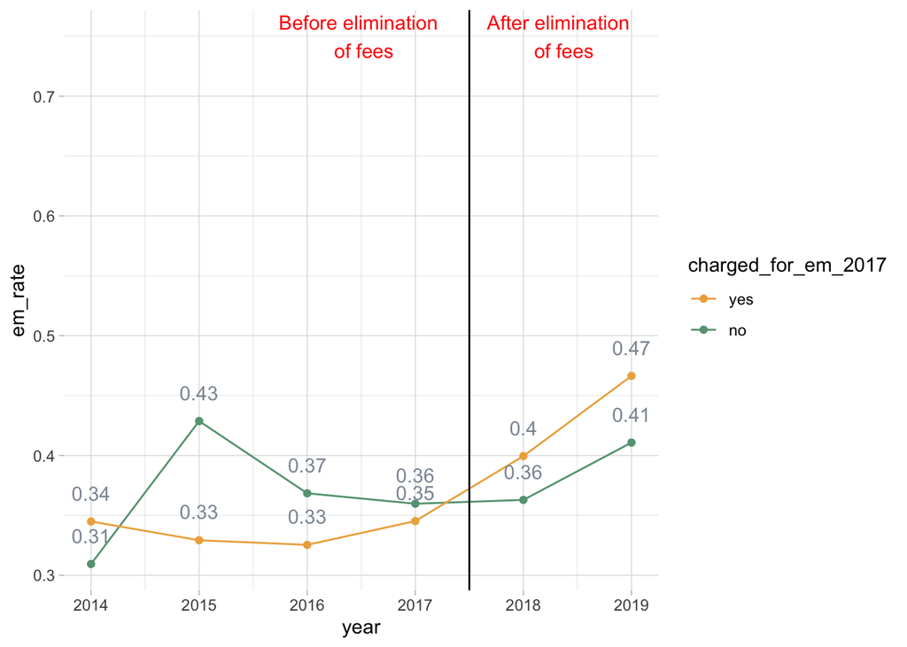

### Summing all EM cases and petitions for counties that charge vs not charge

In this analysis, as with the previous ones, counties are separated by whether they charged for EM or not. Then, for each year, the total number of EM cases for each county is summed, and then the total number of petitions filed in each county. The total EM rate is then calculated, and plotted.

This results in a sort of weighted mean, but instead of weighting by population, as with the first graph it’s weighted by the number of petitions filed by each county.

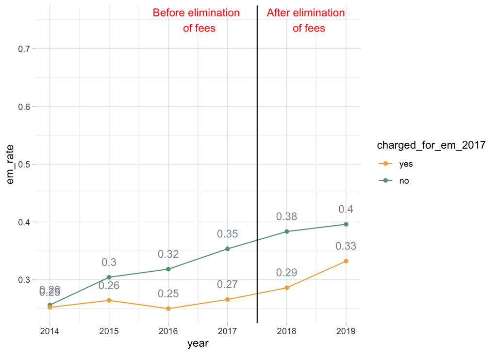

### Plotting all counties

My thought with this one was that it could eventually become an interactive graphic. Each individual county would be displayed in either light grey (counties that didn’t charge), or dark grey (counties that did charge) and when you hover over a given line, it tells you what county it is. Then there would be two colored lines for the actual diff-in-diff calculation lines (so weighted average, unweighted averate, or whatever calculation you choose to do).

Below is just a starting point. You’d probably have to do this using Shiny if you were to do it in R, and below only has each county, not the overall diff-in-diff lines. Obviously the colors are wrong too (and of course there is no interactivity).

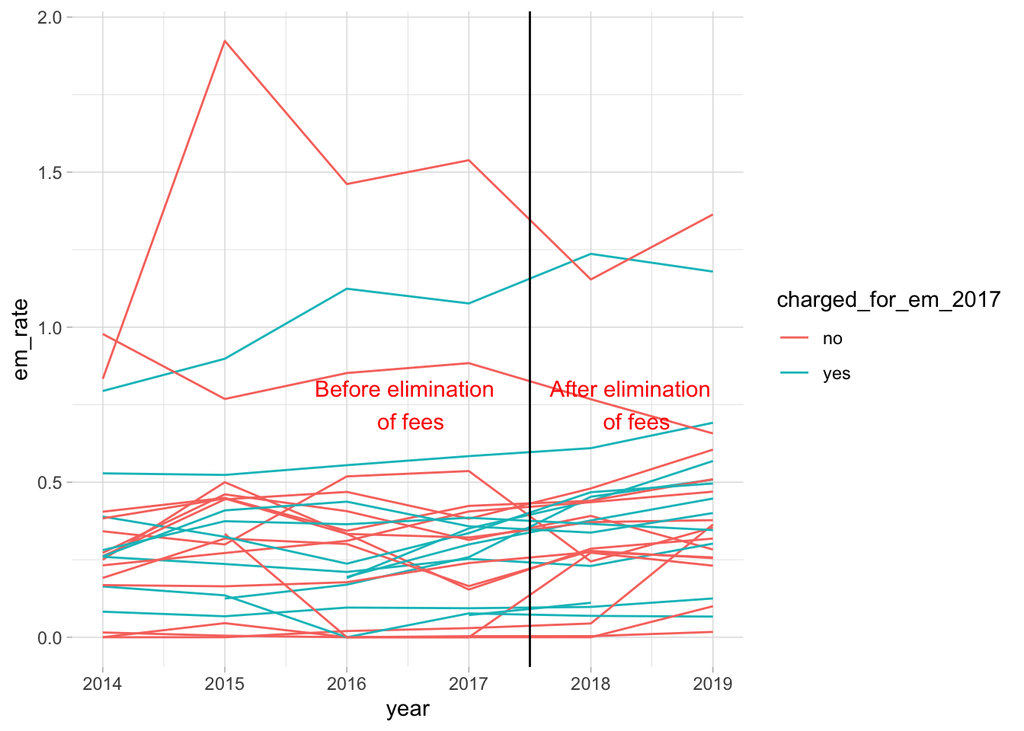